# R Notebook

Using the SDM built from the random forest model, convert the landscape into “habitat” and “non-habitat.” To do this, choose a threshold value in your SDM and convert all cells with predicted outcomes greater than this threshold to 1 and all cells with predicted values below your threshold to 0. Justify your choice of your threshold value. Now calculate the total amount of habitat and mean size of habitat patches based on this new raster (i.e., create patches of “habitat” based on aggregations of cells you deemed 1). How do the habitat amount and patch size values compare between the mesic forest approach and the SDM-based approach? In what situations might you rely on one map over the other?

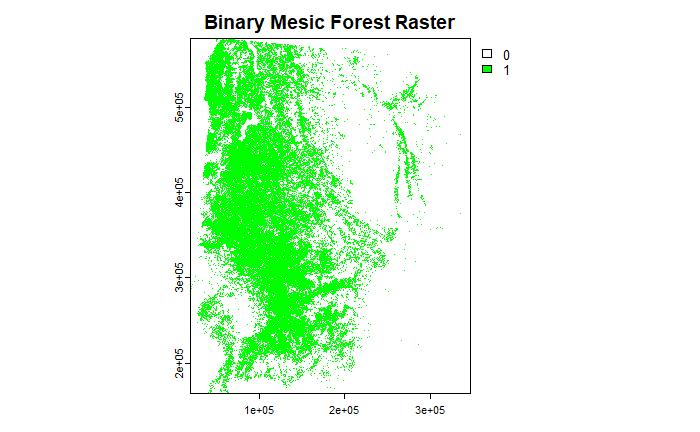

```r
# Plot Mesic Forest
mesic_binary <- ifel(mesic == 1, 1, 0)
plot(mesic_binary, main="Binary Mesic Forest Raster", col=c("white", "green"), legend=TRUE, axes=TRUE)
```

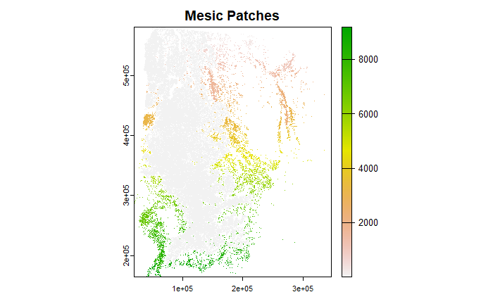

```r
# Mesic Forest Patches
mesic_patches <- patches(mesic_binary, directions=8, zeroAsNA=T)
plot(mesic_patches, main="Mesic Patches", legend=TRUE)
```

```r
# Calculate total area of mesic forest

# Sum mesic forest values
mesic_forest_cells <- sum(values(mesic) == 1, na.rm = TRUE)
non_mesic_forest_cells <- sum(values(mesic) != 1, na.rm = TRUE)
mesic_percent_rounded <- round((mesic_forest_cells/(mesic_forest_cells+non_mesic_forest_cells)*100),2)

# Calculate the area of a single cell (in square meters)
cell_area_square_meters <- res(mesic)[1] * res(mesic)[2]  # Cell resolution (width * height) = 200 m x 200 m
cell_area_sqkm <- cell_area_square_meters/1000000 # Convert to square kilometers

# Calculate total mesic forest area
total_mesic_area <- mesic_forest_cells * cell_area_sqkm

# Calculate mean patch size
mesic_patch_areas <- table(values(mesic_patches))
mesic_mean_patch_size_sqkm <- mean(mesic_patch_areas * cell_area_sqkm)
mesic_mean_patch_size_roundedsqkm <- round(mesic_mean_patch_size_sqkm, 2)

print(paste("In our study area, mesic forest covers",  total_mesic_area, "square kilometers, which accounts for", mesic_percent_rounded, "% of the study area."))
```

```
[1] "In our study area, mesic forest covers 40217 square kilometers, which accounts for 36.82 % of the study area."
```

```r
# Output results
print(paste("Furthermore, the mean patch size of mesic forest is", mesic_mean_patch_size_roundedsqkm, "square kilometers."))
```

[output not shown]

Now calculate the total amount of habitat and mean size of habitat patches based on this new raster (i.e., create patches of “habitat” based on aggregations of cells you deemed 1). How do the habitat amount and patch size values compare between the mesic forest approach and the SDM-based approach? In what situations might you rely on one map over the other?

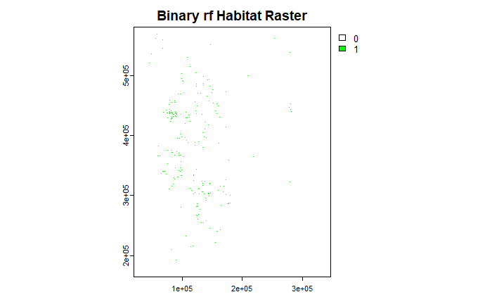

```r
# Plot Habitat Threshold above 0.5 & apply threshold to convert probabilities to binary habitat classification
rf_binary <- ifel(rfMap > 0.5, 1, 0)
plot(rf_binary, main="Binary rf Habitat Raster", col=c("white", "green"), legend=TRUE, axes=TRUE)
```

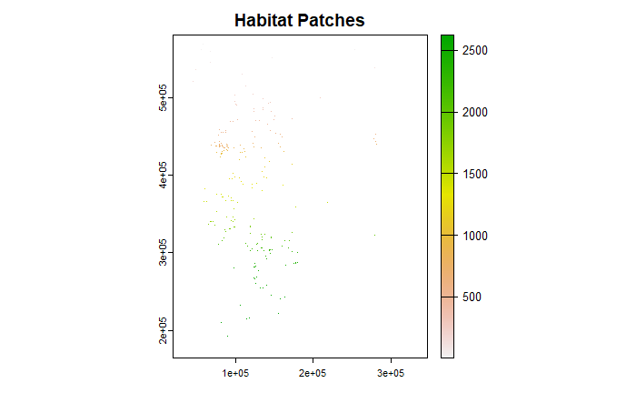

```r
# Step 2: Identify habitat patches
habitat_patches <- patches(rf_binary, directions=8, zeroAsNA=T)
plot(habitat_patches, main="Habitat Patches", legend=TRUE)
```

```r
# Calculate total habitat area
cell_area <- res(rf_binary)[1] * res(rf_binary)[2] # Cell resolution (width * height)
total_habitat_area_sqkm <- (sum(values(rf_binary) == 1, na.rm = TRUE) * cell_area_sqkm) # Convert square km

# Calculate mean patch size
patch_areas <- table(values(habitat_patches))
mean_patch_size_sqkm <- (mean(patch_areas * cell_area_sqkm))
mean_patch_size_roundedsqkm <- round(mean_patch_size_sqkm, 2)

# Output results
print(paste("According to the random forest model (with a >0.5 threshold for habitat), the total habitat area is", total_habitat_area_sqkm, "square kilometers, while the mean patch size is", mean_patch_size_roundedsqkm, "square kilometers."))
```

```
[1] "According to the random forest model (with a >0.5 threshold for habitat), the total habitat area is 298.36 square kilometers, while the mean patch size is 0.12 square kilometers."
```